# SEDA Maps

Amy Luo

11/20/2021

### Congressional District, Political Leaning, and School Funding

**School Expenditure data** are available from: https://exhibits.stanford.edu/data/catalog/db586ns4974

**Political Ideology data** are available from: https://americanideologyproject.com/

- For further information on the measurement methodology for constituent policy preferences, please see this paper by [Tausanovitch and Warshaw (2013)](https://americanideologyproject.com/JOP_Tausanovich_Warshaw_2013.pdf)

Variables of interest include:

- *leaid* : NCES Local Education Agency (District) Code
- *year* : spring of school year
- *grade* : grade level
- *cdcode*, *cd_fips* : congressional district code
- *ppexp_tot* : total per pupil expenditures; tot exp/enrolled
- *ppexp_inst* : instruction expenditures; instr exp/enrolled
- *mrp_mean* : mean policy preferences of citizens in every congressional district estimates using multilevel regression with poststratification

#### Loading the data

```r
# Packages
library(haven)
library(dplyr)
library(USAboundaries)
library(dplyr)
library(sf)
library(leaflet)
library(dplyr)
library(sp)
library(ggplot2)
library(stringr)
library(dplyr)
library(kableExtra)
```

#### Data Prep

```r
# Loading SEDA dataset
full_data_yr <- read_dta("district by year by grade covariates from acs and ccd master_v1_1.dta")

# New data frame of variables of interest
dat <- full_data_yr %>% # filtering to 2013
  filter(year ==2013)

dat <- dat[!duplicated(dat$leaid),] %>% # keeping only one observation per school district (removing grade level layer)
  select('leaid','cdcode','ppexp_tot','ppexp_inst') %>%
  group_by(cdcode) %>%
  mutate(ppexp = mean(ppexp_tot)) %>% # average per pupil expenditure in a congressional district
  mutate(piexp = mean(ppexp_inst)) %>% # average per instructor expenditure in a congressional district
  ungroup()

seda <- dat[!duplicated(dat$cdcode),] %>% # keeping only one observation per congressional district (removing school district layer)
  select(-'leaid',-'ppexp_tot',-'ppexp_inst') # dropping school district ID
```

#### Background: Party Platform Positions on Education

```r
tabd <- read.csv('Amy_Table.csv')
tabd %>%
  kbl(caption="Comparison between Dem and GOP platforms for K-12 education",
      format= "html",
      col.names = c("Topic","Democrat","Republican"),
                  align="l",) %>%
  column_spec(2, background = 'aliceblue') %>%
  column_spec(3, background = 'mistyrose') %>%
  row_spec(0, bold =T, background='lightgrey', color='black') %>%
  kable_paper(bootstrap_options = c("striped", "hover", "condensed", "responsive"),
              full_width = F,
              html_font = "calibri",
              fixed_thead = T,
              position = 'center') %>%
  column_spec(1,bold=T, border_right =T) %>%
  footnote(general='https://www.ascd.org/blogs/what-the-democrats-and-republicans-stand-for-on-education-excerpts-from-party-platforms',
           general_title="Source: ") %>%
  scroll_box(width = "100%", height = "650px")
```

Comparison between Dem and GOP platforms for K-12 education

Topic

Democrat

Republican

Educators

- Public school educators should have the same rights to organize, join a union, and collectively bargain as private sector workers
- Teachers should be protected against “frivolous” lawsuits and should be able to take reasonable actions to maintain discipline and order in the classrooms
- Fight to increase pay and benefits for all educators, in order to help recruit, retain, and reward high-quality teachers and support professionals, and will continue to support measures to help teachers pay for out-of-pocket classroom expenses
- Urge school districts to make use of teaching talent in the business community, STEM fields, and the military
- Support programs to enable support staff to climb the professional ladder within schools and recruit a diverse educational workforce
- Rigid tenure systems should be replaced with merit-based appraoches

Charter Schools

- Students should have multiple public school pathways to be able to access the opportunities they deserve
- Education savings accounts, vouchers, and tuition tax credits
- In support of magnet schools, IB programs, early college high schools
- Ban for for-proft private charter businesses from receiving federal funding
- Charter schools subject to the same accountability as public schools (including racial equity, admissions practices, disciplinary procedures, and school finances
- Oppose private school vouches and other policies that divert taxpayer-funded resources away from public school system

Curriculum and Instruction

- STEAM education for underrepresented students
- Opposed to Common Core, and congratulate the states which have successfully repealed it
- Good understanding of the Bible “being indispensable for the development of an educated citizenry, we encourage state legislatures to offer the Bible in a literature curriculum as an elective in America’s high schools
- Replace family planning for teens with sexual risk avoidance education that sets abstinence until marriage as the responsible and respected standard of behavior

Funding

- Closing the school funding gap by tripling Title I funding (benefits low-income students and incentivize states to adopt progressive funding formulas that direct resources to the schools that need it most
- More money does not necessarily equal better performance (results do not justify spending levels)
- Funding for rural schools, schools in impoverished urban areas impacted by gentrification, and Bureau of Indian Education schools
- Increased support for English learners
- Fully fund the Individuals with Disabilities Education Act for a free appropriate public education and least restrictive environment

Source:

https://www.ascd.org/blogs/what-the-democrats-and-republicans-stand-for-on-education-excerpts-from-party-platforms

#### Mapping Constituent Ideology by Congressional District

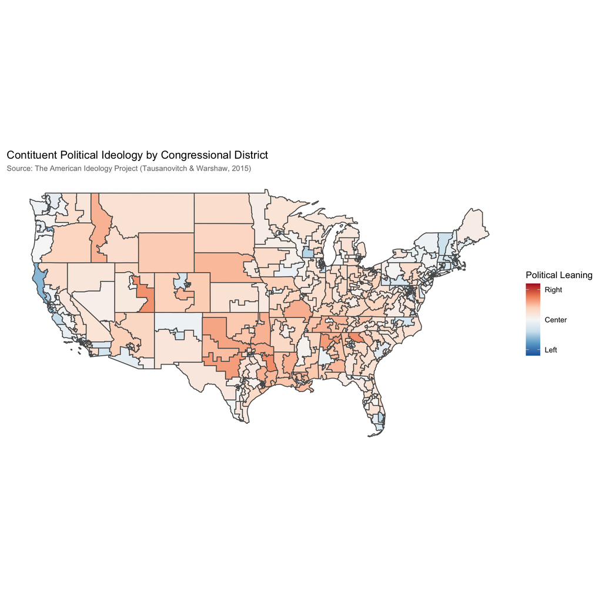

```r
# Loading USAboundaries from GitHub
devtools::install_github("ropensci/USAboundaries")
devtools::install_github("ropensci/USAboundariesData")

# Using USAboundaries package, load the spatial data 2010-2020 Congressional Districts
spatial <- us_congressional()


# Loading congressional ideology data for the 113th Congress from The American Ideology Project, https://americanideologyproject.com/
ideology <- read.csv('cd_113_TW_ideology_estimates.csv')


# Joining political ideology data with the spatial data
## String processing spatial dataset to remove leading zeros in "geoid"
spatial <- spatial %>% # Removing Alaska, Hawaii, and Puerto Rico
  mutate(cd_fips = str_remove(spatial$geoid, "^0+")) %>%
  filter(state_abbr != 'AK') %>%
  filter(state_abbr != 'HI') %>%
  filter(state_abbr != 'PR')

## Selecting columns of interest from ideology dataset
ideology <- ideology %>%
  select(c('cd_fips', 'mrp_mean', 'pres_2012')) %>%
  mutate(cd_fips = as.character(cd_fips))

map <- left_join(spatial, ideology, by = 'cd_fips')

# Mapping
ideology_map <- ggplot() +
  geom_sf(data = map,
          aes(geometry=geometry, fill=mrp_mean), alpha=2) +
  scale_fill_distiller(palette='RdBu',
                       limits = c(-1.2,1.2),
                       direction = -1,
                       breaks=c(-1,0,1),
                       labels=c('Left','Center','Right'),
                       name='Political Leaning') +
  theme(panel.grid.major = element_blank(),
        panel.background = element_blank(),
        axis.title.x=element_blank(),
        axis.text.x=element_blank(),
        axis.ticks.x=element_blank(),
        axis.title.y=element_blank(),
        axis.text.y=element_blank(),
        axis.ticks.y=element_blank(),
        plot.subtitle = element_text(size=9, color='grey45')) +
  labs(title='Contituent Political Ideology by Congressional District',
       subtitle = 'Source: The American Ideology Project (Tausanovitch & Warshaw, 2015)')

ideology_map
```

#### Distribution of Education Funding

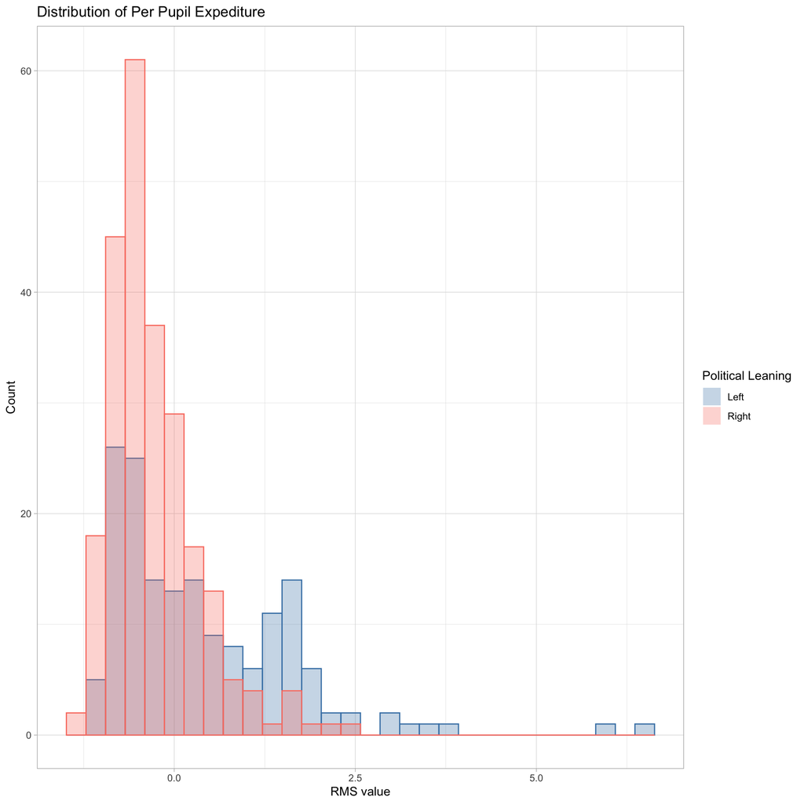

```r
# Joining education dataset with map dataset
seda <- seda %>%
  mutate(cd_fips=as.character(cdcode)) %>%
  select(-'cdcode')

map <- left_join(map, seda, by = 'cd_fips')

# Per pupil Congressional District expenditure
map$z <- scale(map$ppexp)

# Per instructor Congressional District Expenditure
map$z_i <- scale(map$piexp)

# Creating indicator variable for histogram layers
hist <- map %>%
  mutate(left = ifelse(mrp_mean>0, 'Right', 'Left')) # indicator variable for right (1) and left (0)

hist <- hist[!(is.na(hist$left)), ] # removing 1 na value

# Distribution of Student expenditures by Political Ideology
hist_p <- ggplot(hist, aes(x=z,color=left, fill=left)) +
  geom_histogram(position='identity', alpha = 0.3) +
  scale_color_manual(values=c('steelblue','salmon')) +
  scale_fill_manual(values=c('steelblue','salmon')) +
  labs(title='Distribution of Per Pupil Expediture',
       x='RMS value',
       y='Count',
       fill="Political Leaning") +
  guides(color=F) +
  theme_light(); hist_p
```

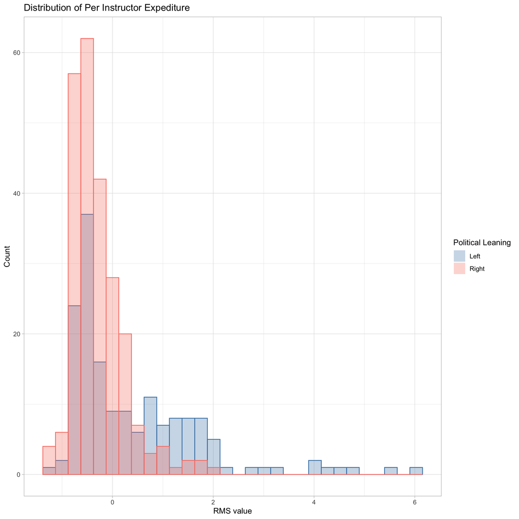

```r
# Distribution of Instructor expenditures by Political Ideology
hist_i <- ggplot(hist, aes(x=z_i,color=left, fill=left)) +
  geom_histogram(position='identity', alpha = 0.3) +
  scale_color_manual(values=c('steelblue','salmon')) +
  scale_fill_manual(values=c('steelblue','salmon')) +
  labs(title='Distribution of Per Instructor Expediture',
       x='RMS value',
       y='Count',
       fill="Political Leaning") +
  guides(color=F) +
  theme_light(); hist_i
```

#### Mapping Average District Spending by Congressional District

```r
# Subsetting for map layers
right <- map %>%
  subset(mrp_mean >0)
left <- map %>%
  subset(mrp_mean <0)

# Mapping per pupil Congressional District expenditure
palette <- colorBin("Greens", domain = c(-1.5,7), bins = 9)

leaflet(map) %>%
  addProviderTiles(providers$CartoDB.Positron, group='Political') %>%
  addTiles(group='Physical') %>%
  addPolygons(data=right,
               opacity=0.5,
               weight=2,
               color='salmon',
               fillColor = ~palette(z),
              fillOpacity = 1,
               highlight=highlightOptions(weight=3,
                                        color='aliceblue',
                                        bringToFront=T),
              group="Politically Right") %>%
  addPolygons(data=left,
              opacity=0.5,
              weight=2,
              color='steelblue',
              fillColor = ~palette(z),
              fillOpacity = 1,
              highlight=highlightOptions(weight=3,
                                      color='aliceblue',
                                      bringToFront=T),
               group='Politically Left') %>%
  addLayersControl(baseGroups=c('Political', 'Physical'),
    overlayGroups=c('Politically Right', 'Politically Left'),
    options=layersControlOptions(collapsed = F))%>%
  addLegend('bottomright',
            pal=palette,
            values=~z,
            opacity=0.5,
            title='Per Pupil Expenditure, scaled')
```

[interactive chart not shown]

```r
# Mapping per instructor Congressional District Expenditure
palette_i <- colorBin("Greens", domain = c(-1.3,7), bins = 9)

leaflet(map) %>%
  addProviderTiles(providers$CartoDB.Positron, group='Political') %>%
  addTiles(group='Physical') %>%
  addPolygons(data=right,
              opacity=0.5,
              weight=2,
              color='salmon',
              fillColor = ~palette_i(z_i),
              fillOpacity = 1,
              highlight=highlightOptions(weight=3,
                                        color='aliceblue',
                                        bringToFront=T),
              group="Politically Right") %>%
  addPolygons(data=left,
              opacity=0.5,
              weight=2,
              color='steelblue',
              fillColor = ~palette_i(z_i),
              fillOpacity = 1,
              highlight=highlightOptions(weight=3,
                                      color='aliceblue',
                                      bringToFront=T),
               group='Politically Left') %>%
  addLayersControl(baseGroups=c('Political', 'Physical'),
    overlayGroups=c('Politically Right', 'Politically Left'),
    options=layersControlOptions(collapsed = F))%>%
  addLegend('bottomright',
            pal=palette_i,
            values=~z_i,
            opacity=0.5,
            title='Per Instructor Expenditure, scaled')
```

[interactive chart not shown]